# How Radio Telescopes Image the Sky

Weclome! In this blog post I'm going to explain how radio telescopes (interferometers) image the sky and how it differs from traditional optical telescopes. I'm a radio astronomer by training and we are known in the field for taking fourier transforms of everything. We live in Fourier space when most astronomers live in image space and natively look at galaxies in the optical, infrared, etc... Throughout this post, when I say image space, I mean the normal x,y,z Euclidean space where an image of a duck looks like a duck to our naked eyes. When I mention Fourier space (or uv space) I am talking about the space where we have decomposed the image into sines and cosines, or spatial frequencies, using the [Fourier transform](https://en.wikipedia.org/wiki/Fourier_transform).

Radio astronomers love Fourier transforms because of [interferometry](https://en.wikipedia.org/wiki/Interferometry): the use of multiple small telescopes which act like one large telescope. Antennas (telescopes) in an interferometer are usually laid out randomly and each baseline, or antenna pairing, measures a specific Fourier mode of the sky (I won't go into details here, but there are excellent resources on the National Radio Astronomy Observatory (NRAO) website. See [here](http://www.cv.nrao.edu/course/astr534/Interferometers1.html)).

The measurement from one baseline of an interferometer is a complex intensity at a given Fourier mode, which is another way of saying that an interferometer natively measures the Fourier transform of the sky. The goal of this post if to build some intuition into how radio astronomers make images of the sky.

Lets start by looking at a single image. I'm using scikit-image's stock photo of the [Hubble Deep Field](https://en.wikipedia.org/wiki/Hubble_Deep_Field) (HDF). The HDF is a deep (long exposure) image from the Hubble Space Telescope (HST). Almost every point of light in the image is a very distant, young galaxy in the universe. In addition to the image, we'll also need matplotlib for plotting and numpy for the Fourier transforms.

We know that we can represent any function as a sum of sines and cosines. An image can be thought of as a function that takes two points in space and returns an intensity. Hence, images can be represented by (spatial) frequency components. Let's take a look at what the Fourier transform of the HDF looks like.

```python
from skimage import data
import matplotlib.pyplot as plt
import numpy as np
%matplotlib inline
```

```python
# only take the 0th channel and treat as a greyscale image.
hdf = data.hubble_deep_field()[...,0]
# Only dealing with square images so cropping.
hdf = hdf[:872, :872]
# 2D Fourier transform of image. Shift so that zero frequencies are in the center of the image.
fourier_hdf = np.fft.fftshift(np.fft.fft2(hdf))
```

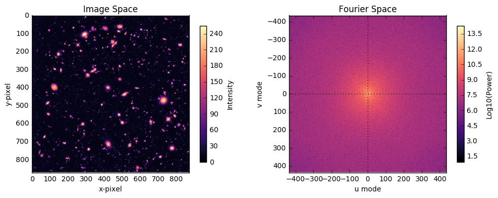

```python
def plot_image(hdf, title='', **kwargs):
    plt.imshow(hdf, cmap='magma', **kwargs)
    plt.title(title)
    plt.xlabel('x-pixel')
    plt.ylabel('y-pixel')
    clb = plt.colorbar(shrink=.87)
    clb.set_label('Intensity')

plt.figure(figsize=(12,4))
plt.subplot(121)
plot_image(hdf, title='Image Space')

plt.subplot(122)
# get bins of the fourier modes and use for extent of image.
fourier_bins = np.arange(-hdf.shape[0]/2+1, hdf.shape[0]/2+1)
plt.imshow(np.log10(np.abs(fourier_hdf)**2), cmap='magma', extent=(fourier_bins[0], fourier_bins[-1], fourier_bins[-1], fourier_bins[0]))
clb = plt.colorbar(shrink=.87)
clb.set_label('Log10(Power)')
plt.title('Fourier Space')
plt.xlabel('u mode')
plt.ylabel('v mode')
plt.hlines(0, -hdf.shape[0]/2 + 1, hdf.shape[0]/2, linestyles='dotted');
plt.vlines(0, -hdf.shape[0]/2 + 1, hdf.shape[0]/2, linestyles='dotted');
```

The left is the image of the deep field (as seen in one colorband) where the axes representing the x and y pixel position and the color represents the intensity in a given pixel. The right is the log of the Power Spectrum (defined as the absolute value squared of the Fourier Transform) for the image where the axes correspond to the fourier modes in the x and y direction, called u and v, respectively. The colorscale represents the Log base 10 of the power in a given fourier mode. The dotted lines intersect at the u=v=0.

Focusing on the right hand side we can try to predict what the Fourier transform should roughly look like by trying see to what modes are dominant in the image. When we talk about Fourier modes of an image, we're talking about "scales" in the x and y directions of the image. More precisely we're looking at sinewaves in each cardinal direction of the image and seeing what frequencies (of the sines and cosines) are represented in the image. For example, in the HDF, we notice a lot of coherent structure on small scales (the galaxies and foreground stars in the image). These structures correspond to small scales, or large fourier modes (large frequencies). From the image on the right, we see that there is non-zero power on these small scales in Fourier space (large u and v values). Contrasted with the small scale galaxy structures, the voids (empty space) are large scale structures. Since there are more voids than galaxies, there is a lot of power on large scales, or small u and v modes (in addition to the fact that these structures are more coherent in the sense that there is little variability in the voids). Hence, we expect to see more power on large scales, or small Fourier modes (closer to the center of the image), which is exactly what the right plot shows.

Now that we've built some intuition about Fourier transforms of images, lets take a look at what happens in interferometry where we sample a fraction of the Fourier modes.

# Sampling the Fourier Plane

In the previous section, we looked at the Fourier transform of the HDF. If we took its inverse Fourier transform, we would recover the original HDF image perfectly. Next, let’s see how information is lost when we attempt to reconstruct the image by measuring only certain Fourier modes. Later, we'll see how this is similar to the way interferometers make images of the sky.

Suppose we wanted to reconstruct the HDF image by measuring certain Fourier modes. Which modes would we want to use to accurately recover the image? Obviously we would like to use all the modes and not lose any information, but sometimes there is need for compressing the image or we do not have access to certain modes or we only care about certain modes. But can we only sample a few modes to do a decent job? Which modes contain most of the information?

Let's first start by only using the first few low order modes from the Fourier plane. I've created a mask that keeps the modes inside of a 72x72 pixel box (in uv space) around 0.

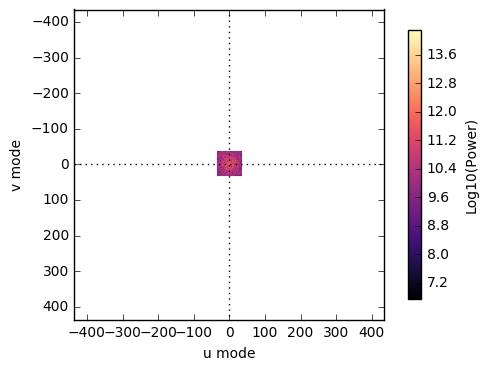

```python
# create mask
size = hdf.shape[0]
center_pixel = size/2
mask = np.ones(hdf.shape, dtype=bool)
n_modes = 36
mask[center_pixel-n_modes:center_pixel+n_modes, center_pixel-n_modes:center_pixel+n_modes] = 0

# Mask the fourier plane with mask. Use masked arrays for ease of use.
masked_fourier_hdf_low = np.ma.masked_array(fourier_hdf, mask=mask)

# Reproduce image.
hdf_low = np.fft.ifft2(np.fft.ifftshift(masked_fourier_hdf_low.filled(0)))

# Plot fourier plane
plt.figure(figsize=(6,4))
plt.subplot(111)
plt.imshow(np.ma.log10(np.abs(masked_fourier_hdf_low)**2), cmap='magma', extent=(fourier_bins[0], fourier_bins[-1], fourier_bins[-1], fourier_bins[0]))
clb = plt.colorbar(shrink=.87)
clb.set_label('Log10(Power)')
plt.xlabel('u mode')
plt.ylabel('v mode')
plt.hlines(0, -hdf.shape[0]/2 + 1, hdf.shape[0]/2, linestyles='dotted');
plt.vlines(0, -hdf.shape[0]/2 + 1, hdf.shape[0]/2, linestyles='dotted');
```

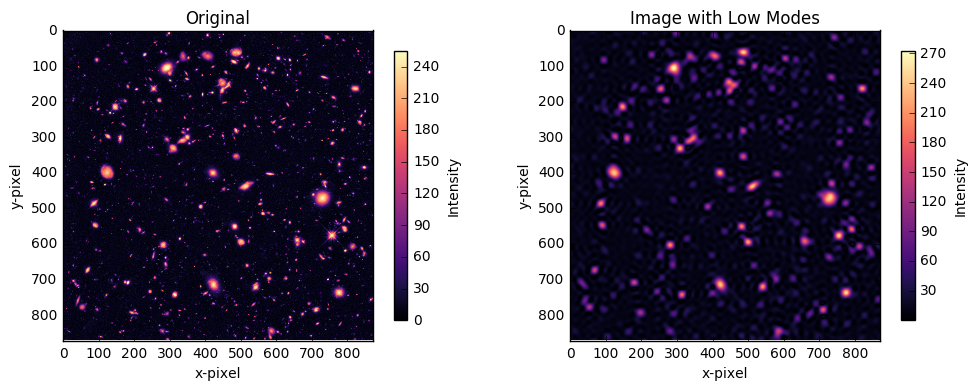

```python
fig = plt.figure(figsize=(12,4))
plt.subplot(121)
plot_image(hdf, title='Original')

plt.subplot(122)
plot_image(np.abs(hdf_low), 'Image with Low Modes')
```

On the left is the original image and on the right is the reconstructed image with only low order Fourier modes. Notice that because we didn't include the high Fourier modes, the fine structure/detail is not present in the reconstructed image. It does a good job of giving us a picture of the brightest and most extended galaxies, but can't reproduce the small galaxies.

Now let's try the reverse. Using high order modes only we find that the fine structure in the image is present and extended sources are not there. However, if we zoom into a source we find ripples surrounding a source. This is an effect of the Fourier transform due to the use of the top hat window function in the FFT (the fft of a top hat window function is a sync function which causes the sidlobe ringing shape). Different [window functions](https://en.wikipedia.org/wiki/Window_function) will do better in terms of ringing.

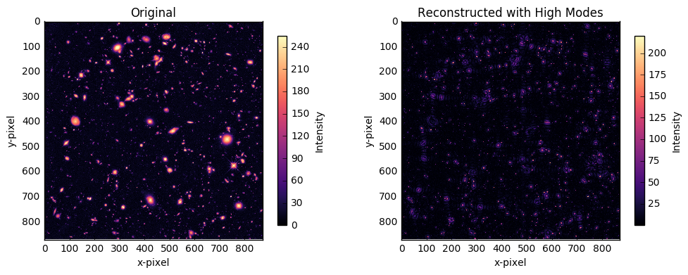

```python
# Mask out low modes and keep high order modes.
# Mask the fourier plane with mask. Use masked arrays for ease of use.
masked_fourier_hdf_high = np.ma.masked_array(fourier_hdf, mask=~mask)

# Reproduce image.
hdf_high = np.fft.ifft2(np.fft.ifftshift(masked_fourier_hdf_high.filled(0)))

# plot
fig = plt.figure(figsize=(12,4))
plt.subplot(121)
plot_image(hdf, title='Original')

plt.subplot(122)
plot_image(np.abs(hdf_high), title='Reconstructed with High Modes')
```

To recap, we showed that we can sample the Fourier plane (FFT of an image) any way we want to recover different types of information in the original image. Generically, keeping low (high) order modes will reproduce the large (small) scale structure. Now let's see how this is done in radio astronomy. Now let’s see how image reconstruction is done with radio interferometry.

## Imaging in Radio Astronomy

I mentioned before that in radio interferometery, different baselines are sampling different Fourier modes. Specifically, the Fourier modes sampled are proportional to the distance between two antennas (the baseline length) and the orientation (hence the baseline vector). For example, a baseline of length 10m measures a different Fourier mode than a baseline of length 20m. Additionally, a baseline oriented in the N/S direction measures a different Fourier mode than a baseline oriented in the E/W direction. Depending on the nature of the experiment you are trying to conduct, the placement of your antennas on the ground plays an important role in how well you can make images of the sky. Since antenna pairs measure Fourier modes, in order to make an image of the sky with an interferometer we simply need to grid the complex intensity measurements (the native measurement of the interferometer) in the Fourier plane and inverse Fourier transform to get our image.

To get a feel for some array configurations let's look at some examples:

### Rectangular Grids

We first look at a rectangular grid of antennas (such as the [HERA](http://reionization.org/) or [PAPER](http://eor.berkeley.edu/) experiments). Below we show the array layout and the Fourier sampling of such an array.

Note: The sky is a real valued quantity so when we calculate the coverage, we get both the Fourier mode measured and its complex conjugate.

```python
# let's define some helpful functions first.
def get_fourier_coverage(positions):
    """Get the fourier plane coverage of array with antenna coordinates in positions.

    Every pair of antennas in an array that has a unique orientation and separation
    measures a different fourier mode. This function measures the fourier coverage by
    taking the vector difference between every antenna pair.

    Args:
        positions (list): List of tuples or antenna positions (x,y).

    Returns:
        list : list of the fourier modes being sampled.
    """
    uv_plane_points = []
    for i, ai in enumerate(positions):
        for k, ak in enumerate(positions[i:]):
            uv = np.array(ai) - np.array(ak)
            uv_plane_points.append((uv[0], uv[1]))
            uv_plane_points.append((-uv[0], -uv[1]))
    return uv_plane_points


def plot_fourier_coverage(uv_points):
    """Plot the fourier coverage as a scatter plot given list of uv pairs."""
    for uv in uv_points:
        plt.scatter(uv[0], uv[1])
        plt.scatter(-uv[0], -uv[1])
    plt.title('Fourier Coverage')
    plt.xlabel('u mode')
    plt.ylabel('v mode')

    return None


def sample_image(points, fim):
    """Use a set of coordinates in fourier space to sample an image.

    This function first creates a mask given a list of coordinates in the
    Fourier domain and applies that to the Fourier transform of the
    true image and then inverse fourier transforms to return the
    reconstructed image.

    Args:
        points (list): set of coordinates in fourier space to sample.
        fim (array): Fourier image to sample

    Return:
        array: Sampled image (in real space)
    """
    mask = np.zeros(fim.shape, dtype=int)
    center = mask.shape[0]/2, mask.shape[0]/2
    for pt in points:
        mask[center[0]-pt[1], center[0]+pt[0]] += 1
    masked_fim = fim * mask
    masked_im = np.fft.ifft2(masked_fim)
    return masked_im


def plot_antenna_positions(antenna_positions):
    """Plot antenna positions as a scatter plot given a list of coordinate positions"""
    for i in antenna_positions:
        plt.scatter(i[0], i[1])
    plt.ylabel('Y-Position (meters)')
    plt.xlabel('X-Position (meters)')
    plt.title('Array Positions')

    return None
```

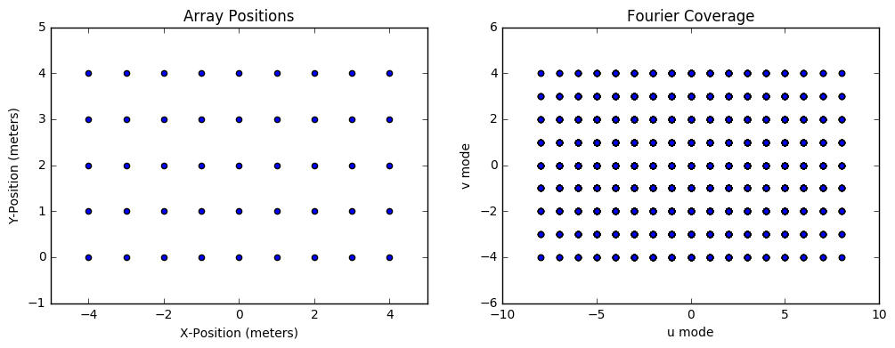

```python
# make antenna positions and plot
# array centered at zero for aesthetic purposes. Doesn't matter in terms of Fourier coverage.
antenna_positions = [(i,k) for i in range(-4,5) for k in range(5)]

plt.figure(figsize=(12,4))
plt.subplot(121)
plot_antenna_positions(antenna_positions)

plt.subplot(122)
uv_plane_points_rect = get_fourier_coverage(antenna_positions)
plot_fourier_coverage(uv_plane_points_rect)
```

Now to see what kind of image we would get using this antenna configuration of the HDF we take the original Fourier image and multiply by the sampling pattern in the uv (Fourier) plane. We are multiplying the sampling pattern in the uv plane because these are the only modes on sky we have access to given the array configuration, therefore we can only sample those modes in the original image. Fourier transforming the resultant sampled image in Fourier space, an image (in real space) is produced. Here is what we get when we do that with the above array layout.

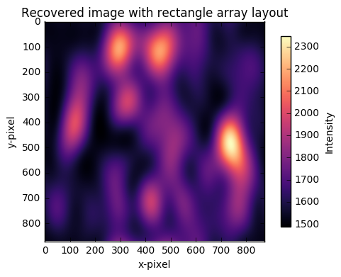

```python
rect_im = sample_image(uv_plane_points_rect, fourier_hdf)
plt.figure()
plot_image(np.abs(rect_im), title='Recovered image with rectangle array layout')
```

The image is pretty bad. If this was the image that we made using an interferometer, we would probably think that there are large, extended sources on the sky that are very bright. However, we know (since we know what the original image looks like, which is not the case in reality: we don't know what the actual sky looks like) that there are many smaller sources that comprise the HDF, and this reconstruction is essentially smoothing the image on large scales. Hence, we would potentially mischaracterize the physics and the implications of the astrophysical sources in this image.

# An imaging configuration

To make good images, interferometers need to sample many Fourier modes, leading to more antennas being placed on the ground seemingly randomly so that there are many different types of baselines (short, long, etc..), with little overlap. Instead of trying to optimize such a configuration we can use [Costas arrays](https://en.wikipedia.org/wiki/Costas_array) . Costas arrays are NxN matrices such that no two elements share a row or column and the displacement vector between any two elements is unique.

The antenna layout and its Fourier coverage is shown below for the Costas array imaging configuration using 36 antennas. Notice that antennas are placed on the ground randomly (atleast to the naked eye). Another plus side for using Costas arrays is that Fourier modes are only sampled once so that the coverage in the Fourier plane is uniform.

```python
def costas_array(p, N, alpha):
    """Create a NxN Costas array using the Welch method.

    You must choose p, N, and alpha that satisfy the conditions below.

    Args:
        p (int): prime number
        N (int): integer less than p.
        alpha (integer): integer such that alpha^N mod p = 1 and alpha^i mod p != 1 for 0<i<N

    Returns:
        array: shape NxN, where 1 is antenna position and 0 is empty
    """
    antennas = np.zeros(shape=(N,N))
    for i in range(1,N+1):
        x = i
        y = alpha**i % p
        antennas[x-1, y-1] = 1
    return antennas
```

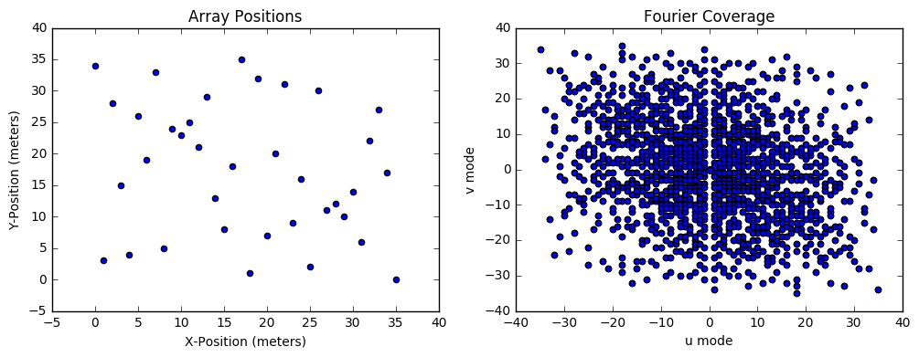

```python
ant_array = costas_array(37, 36, 35)
antenna_positions = zip(*np.where(ant_array))

plt.figure(figsize=(12,4))
plt.subplot(121)
plot_antenna_positions(antenna_positions)

plt.subplot(122)
uv_plane_points = get_fourier_coverage(antenna_positions)
plot_fourier_coverage(uv_plane_points)
```

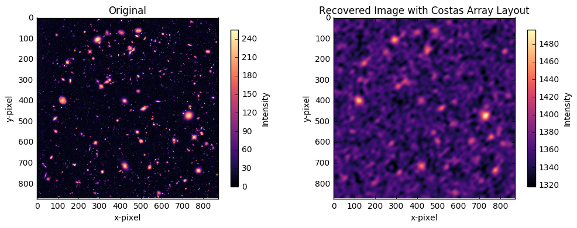

```python
plt.figure(figsize=(12,4))
plt.subplot(121)
plot_image(hdf, title='Original')

plt.subplot(122)
min_image = sample_image(uv_plane_points, fourier_hdf)
plot_image(np.abs(min_image), 'Recovered Image with Costas Array Layout')
```

Comparing the figures from the imaging and rectangular array configurations, we find that the imaging array does better. However, it doesn't reproduce the original exactly. Most of the bright sources can be seen to a certain extent in the image, where as for the rectangular array, we just see the large distribution of intensity on the sky. In order to make a better image, we need to have more antennas and longer baselines to cover the higher Fourier modes.

## Last thoughts

This was a very quick introduction to imaging with interferometers. Some added complications with real radio interferometery include the response of the antennas and types of weighting functions used when fourier sampling (where and how do I put a sample into the Fourier plane, also known as gridding).

Additionally, there is a whole field based on image reconstruction. What we've shown in the plots above is actually called a "dirty image". It is the image you get without any sort of cleaning etc. However, since in reality there is a beam pattern that is convolved with the image, astronomers use algorithms to deconvolve that pattern out and reconstruct a better image.

I hope that I have shed some light on how imaging is done with radio interferometers and that you have learned some interesting stuff that may be useful for you in your own work! Thanks!